# Ripple Effect Site Report

10 September 2025

[figure not shown]

Ripple Effect is working with local volunteers to monitor water quality and pollution across 13–15 sites along three, 10km stretches of the Upper River Medway, including the Grom and Eridge Stream. You can explore all our monitoring locations and data on our [interactive map](https://project-ripple-effect.co.uk/map) - just click on a site and scroll to see what we’ve found.

Each month, our citizen scientists test for key indicators of water health: ammonia, phosphate, conductivity, and temperature. We aim for surveys to be carried out on the same Monday between 10am and 2pm, helping us capture consistent data and spot pollution incidents.

We also use the [Riverfly](https://www.riverflies.org/) method to assess ecological health. Volunteers carry out a “kick sample” in the riverbed, identifying and counting eight groups of freshwater invertebrates. These creatures vary in their tolerance to pollution, so their presence or absence helps us calculate a water quality score.

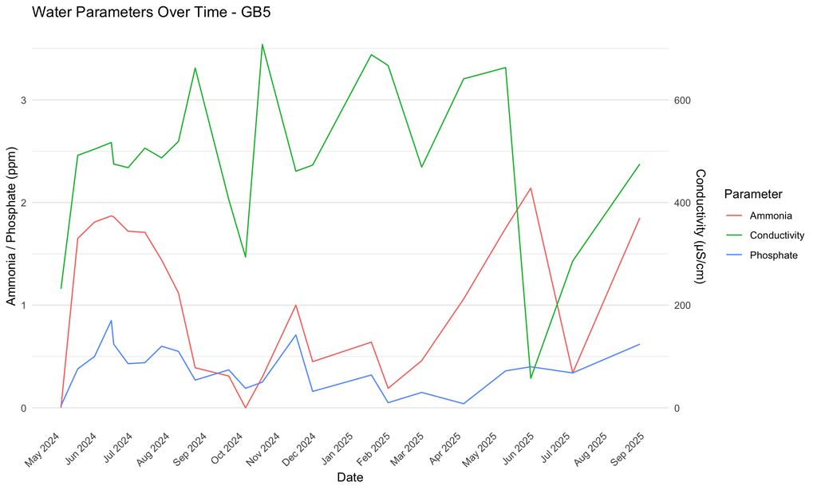

#### **Plot Overview**

This plot shows ammonia, phosphate and conductivity data for the selected site.

**Site code indicates the location:**  
**FR**: Forest Row stretch  
**HF**: Hartfield stretch  
**GB**: Groombridge stretch

**Axes:**  
**Left axis**: Ammonia and phosphate concentrations (ppm)  
**Right axis**: Conductivity (µS/cm)  
**X-axis**: Month and year of sampling — useful for spotting seasonal patterns and long-term trends.

**Healthy Water Quality Thresholds:**  
**Ammonia**: < 1 ppm  
**Phosphate**: < 0.1 ppm  
**Conductivity**: < 500 µS/cm (sudden changes may signal pollution)

#### **How to Interpret the Plot**

Use the plot to identify unusual spikes or drops in water quality indicators, which may suggest:  
**Ammonia**: Toxic at high levels; often linked to agricultural runoff or industrial discharge.  
**Phosphate**: Elevated levels may indicate sewage or nutrient pollution, potentially leading to eutrophication.  
**Conductivity**: Natural variation is expected, but sharp increases may point to chemical contamination or salt intrusion.

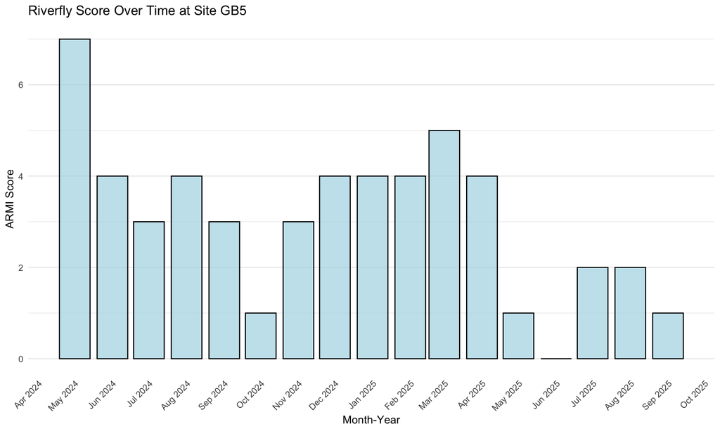

#### **ARMI Score Over Time**

This figure shows the ARMI (Anglers’ Riverfly Monitoring Initiative) score over time. The score is based on the number of freshwater invertebrates found from eight indicator groups, which vary in their tolerance to pollution. It provides a useful snapshot of ecological water quality.

**Site code indicates the location:**  
**FR**: Forest Row stretch  
**HF**: Hartfield stretch  
**GB**: Groombridge stretch

#### **Trigger levels and monitoring**

Sites that are monitored regularly (at least 10 times over 12 months) are assigned a **trigger level**. If a site’s ARMI score falls below this threshold, it may indicate a pollution event. To confirm this, a follow-up survey must be carried out within 48 hours. If confirmed, the Environment Agency (EA) must be notified to investigate.

**Trigger levels**:

- Level 3: FR5, GB3, GB5
- Level 4: HF3, GB2

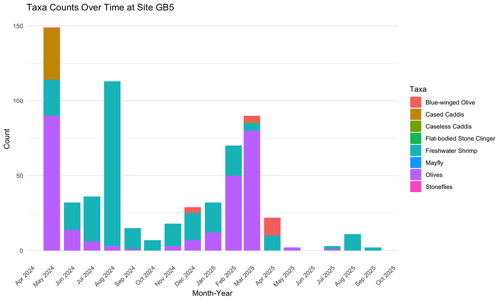

#### **Monthly Invertebrate Counts by Taxa**

This figure shows total number of invertebrates recorded each month at the selected site, broken down by the eight Riverfly indicator groups. Each coloured segment in the stacked bars represents a different taxonomic group, allowing you to assess both overall abundance and shifts in community composition.  
Because these groups vary in their sensitivity to pollution, changes in their relative proportions offer insight into ecological health:

- A diverse assemblage with pollution-sensitive taxa suggests good water quality.
- Dominance by tolerant groups may indicate environmental stress or degradation.  
  **Site code indicates the location:**  
  **FR**: Forest Row stretch  
  **HF**: Hartfield stretch  
  **GB**: Groombridge stretch

#### **How to use this figure:**

- **Track seasonal patterns** in invertebrate abundance, noting natural fluctuations such as spring and summer emergence versus winter dormancy.
- **Detect changes in community structure** over time, which may reflect pollution events, habitat changes, or restoration efforts.

### GLOSSARY

#### Water Parameters

**Conductivity** is a measure of water quality and is affected by the presence of dissolved solids such as those from sewage effluent. Conductivity naturally varies between 150 and 500 μs/cm; above this range could indicate water not suitable for certain species. A sudden change may indicate the onset of a polluting discharge.  
**Phosphate** is a common constituent of fertilisers, manure, industrial effluent, and organic wastes in sewage. In excess it can cause a reduction in dissolved oxygen in rivers, caused by excessive algal growth. Without dissolved oxygen in the water, aquatic animals cannot survive.  
**Ammonia** is an important natural resource in nature, but high levels can be toxic, causing lower reproduction and growth or death. It can be discharged into rivers from a range of sources including agricultural fertilisers and sewage effluent. It’s important to measure temperature at same time as this can impact the levels found in freshwater. Concentrations in unpolluted rivers range from 0.2 to 1.0 ppm. Tests with a reading of 3.0 ppm or above should be repeated to confirm, then reported to the EA.

#### Water Quality

**Riverfly ARMI scores** are determined by collecting the animals from the river in a net following a standardised protocol, identifying 8 specific groups of animals (insect larvae and freshwater shrimp), and counting how many there are in each group. The score has been validated as a reliable measure to monitor changes in water health.

#### Biodiversity

**Environmental DNA (eDNA)** is DNA that organisms shed into their environment such as via skin, hair, faeces or mucus. By filtering water samples from the river, we can collect the DNA of species present as a non-invasive measure of biodiversity.